# DSI_Lab_5_Hierarchical_Clustering

Dingxin Lu

11/29/2021

[My Github link] https://github.com/sydneydlu98/DSI_Lab_5_Hierarchical_Clustering

```r
## load the data
data <- read.csv("Ch10Ex11.csv", header = FALSE)

## load all the packages
library(amap)
```

# Problem 1

Use the gene expression data in Ch10Ex11.csv that is provided for you on Canvas. This is gene expression data that consists of 40 tissue samples with measurements on 1,000 genes. The first 20 samples are from healthy patients, while the second 20 are from a diseased group.

1. Load the data – note that there is no header so you will need to read this in without one. Note that rows in this dataset represent genes and columns subjects. You will need to transpose the data using the function t() before you cluster (as we would like to cluster subjects).
2. Scale the data.
3. Calculate the Euclidean distance between the observations.
4. Perform hierarchical clustering on the data using the below linkages, and plot the dendograms for each linkage:
- complete linkage
- single linkage
- average linkage
5. Determine clusters for 2 groups from all three methods using cutree().
6. Make three contingency tables for the results. A contingency table is a tabular representation of categorical data that typically shows the frequency of the combinations of the two variables (ie. a 2x2 table). Here we would like to show a table of our clustering versus the true disease status of the subjects. Create a variable of the disease status for the 40 tissue samples. Use the clustering that you obtained in the previous step. Create a table of the two variables using table(). Comment on what you observe.

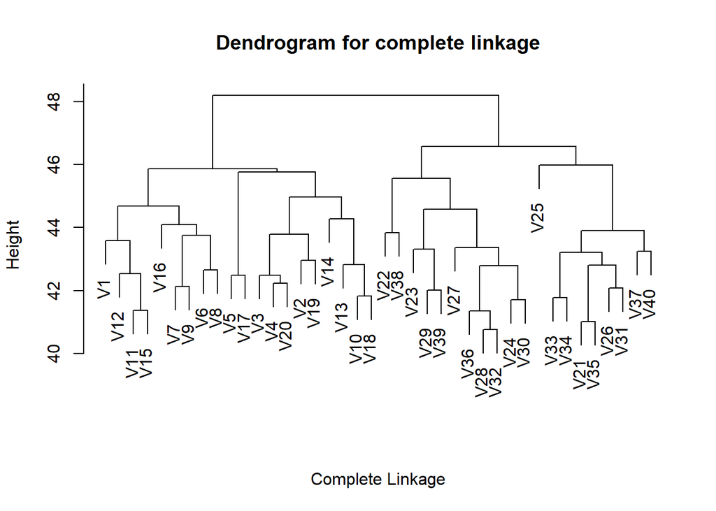

```r
## transpose the data
transpose <- t(data)

## Scale the data
scaled_data <- scale(transpose)

## Calculate the Euclidean distance between the observations
d <- dist(scaled_data)

## hierarchical clustering on the data by using complete linkage
hc_complete <- hclust(d,
                      method = 'complete')
## Plot the dendograms for complete linkage
plot(hc_complete,
     main = "Dendrogram for complete linkage",
     xlab = "Complete Linkage",
     sub = "")
```

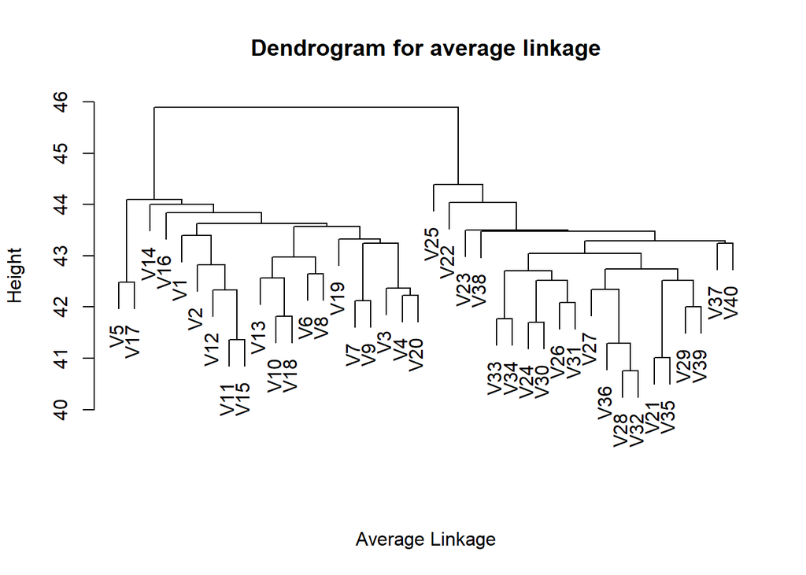

```r
## hierarchical clustering on the data by using average linkage
hc_average <- hclust(d,
                     method = 'average')
## Plot the dendograms for average linkage
plot(hc_average,
     main = "Dendrogram for average linkage",
     xlab = "Average Linkage",
     sub = "")
```

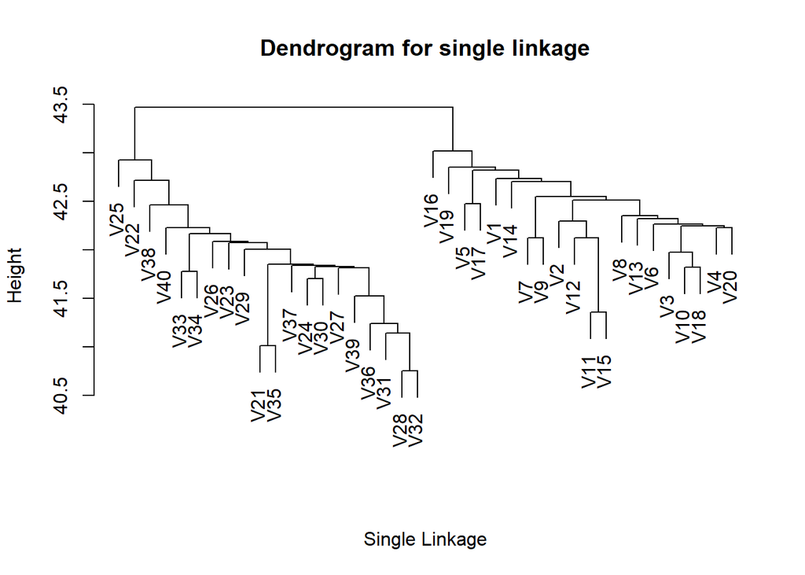

```r
## hierarchical clustering on the data by using single linkage
hc_single <- hclust(d,
                    method = 'single')
## Plot the dendograms for single linkage
plot(hc_single,
     main = "Dendrogram for single linkage",
     xlab = "Single Linkage",
     sub = "")
```

```r
## Determine clusters for 2 groups (k=2) from all three methods
hclusters_complete <- cutree(hc_complete,
                             k = 2)
hclusters_average <- cutree(hc_average,
                            k = 2)
hclusters_single <- cutree(hc_single,
                           k = 2)

# Make three contingency tables
## Contingency table for complete linkage
complete <- data.frame(hclusters_complete)
status <- c("healthy", "healthy", "healthy", "healthy", "healthy", "healthy", "healthy", "healthy", "healthy", "healthy", "healthy", "healthy", "healthy", "healthy", "healthy", "healthy", "healthy", "healthy", "healthy", "healthy","diseased", "diseased", "diseased", "diseased", "diseased", "diseased", "diseased","diseased","diseased","diseased", "diseased", "diseased", "diseased", "diseased", "diseased", "diseased", "diseased","diseased","diseased","diseased")
complete$status <- status
table(true = status,
      cluster_complete = hclusters_complete)
```

```
##           cluster_complete
## true        1  2
##   diseased  0 20
##   healthy  20  0
```

```r
## Contingency table for average linkage
average <- data.frame(hclusters_average)
average$status <- status
table(true = status,
      cluster_average = hclusters_average)
```

```
##           cluster_average
## true        1  2
##   diseased  0 20
##   healthy  20  0
```

```r
## Contingency table for single linkage
single <- data.frame(hclusters_single)
single$status <- status
table(true = status,
      cluster_single = hclusters_single)
```

```
##           cluster_single
## true        1  2
##   diseased  0 20
##   healthy  20  0
```

# Problem 2

An alternative to using Euclidean distance is to use a correlation distance. The function dist() does not support this, so we will use amap::Dist(). Perform steps 3-6 as above, except use amap::Dist() with method = ‘correlation’ for step 3.

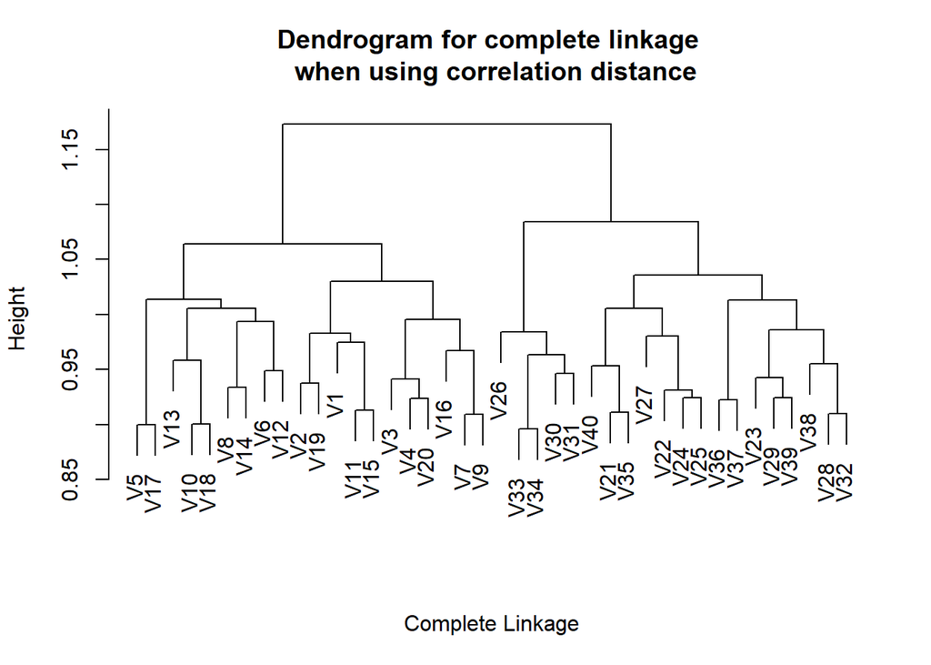

```r
## use a correlation distance to calculate the Euclidean distance
dd <- amap::Dist(scaled_data, method = 'correlation')

## hierarchical clustering on the data by using complete linkage
cor_complete <- hclust(dd,
                       method = "complete")
## Plot the dendograms for average linkage by using a correlation distance
plot(cor_complete,
     main = "Dendrogram for complete linkage \n when using correlation distance",
     xlab = "Complete Linkage",
     sub = "")
```

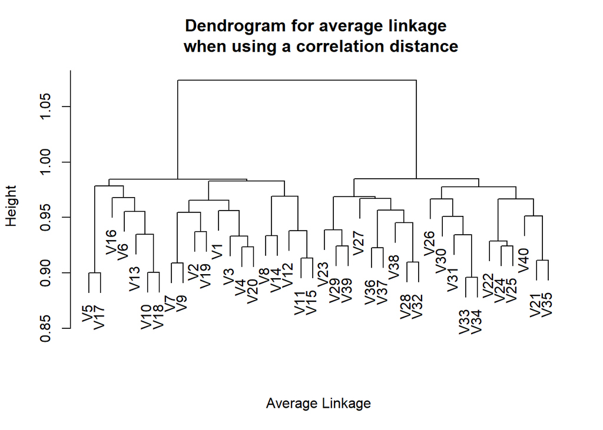

```r
## hierarchical clustering on the data by using average linkage
cor_average <- hclust(dd,
                      method = 'average')
## Plot the dendograms for average linkage by using a correlation distance
plot(cor_average,
     main = "Dendrogram for average linkage \n when using a correlation distance",
     xlab = "Average Linkage",
     sub = "")
```

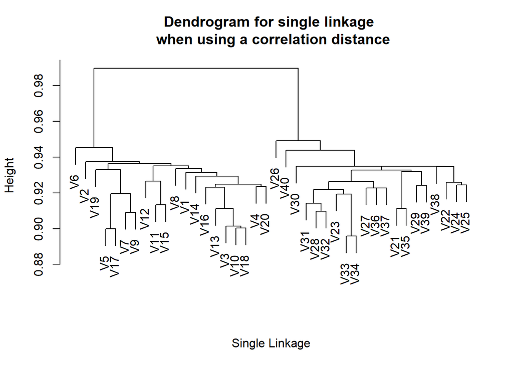

```r
## hierarchical clustering on the data by using single linkage
cor_single <- hclust(dd,
                     method = 'single')
## Plot the dendograms for single linkage by using a correlation distance
plot(cor_single,
     main = "Dendrogram for single linkage \n when using a correlation distance",
     xlab = "Single Linkage",
     sub = "")
```

```r
## Determine clusters for 2 groups (k=2) from all three methods
hcor_complete <- cutree(cor_complete,
                        k = 2)
hcor_average <- cutree(cor_average,
                       k = 2)
hcor_single <- cutree(cor_single,
                      k = 2)

# Make three contingency tables
## Contingency table for complete linkage
complete2 <- data.frame(hcor_complete)
complete2$status <- status
table(true = status,
      cluster_complete = hcor_complete)
```

```
##           cluster_complete
## true        1  2
##   diseased  0 20
##   healthy  20  0
```

```r
## Contingency table for average linkage
average2 <- data.frame(hcor_average)
average2$status <- status
table(true = status,
      cluster_average = hcor_average)
```

```
##           cluster_average
## true        1  2
##   diseased  0 20
##   healthy  20  0
```

```r
## Contingency table for single linkage
single2 <- data.frame(hcor_single)
single2$status <- status
table(true = status,
      cluster_single = hcor_single)
```

```
##           cluster_single
## true        1  2
##   diseased  0 20
##   healthy  20  0
```